# Biostats Lecture 1: Descriptive Statistics

## Public Health 783

### Ralph Trane

### University of Wisconsin–Madison<br><br>

### Fall 2019

# Learning Objectives

1. Understand why descriptive statistics is important, and useful

2. Know the difference between discrete and continuous variables/data

3. Have some ideas of which summaries and figures are appropriate for different types of data

# Descriptive Statistics

* What: the art of describing data with few important measures ('summary statistics')

* Why:
    - know your population!!
    - explore your data

* How: try to get an idea of the distributions of variables included

- what's a distribution?!
    - what's a variable?!

# Data Types

Two general data types:

* Discrete data
    - categorical
        - no natural ordering
        - examples: sex, race, blood type, political orientation, etc.
    - ordinal
        - naturally ordered
        - educational level, age groups, disease severity scales, etc.
    - summarized by
        - frequency counts
        - relative frequencies

* Continuous data
    - numerical
        - examples: age, height, weight, BMI, proportions, etc.
    - infinite (uncountable, actually...) number of potential values
    - summarized by
        - location measures
        - spread/variation measures

# Example

[Framingham Heart Study](./fhs_descriptives.html)

What NOT to do with categorical data.

A.K.A. my least favorite chart of all time...

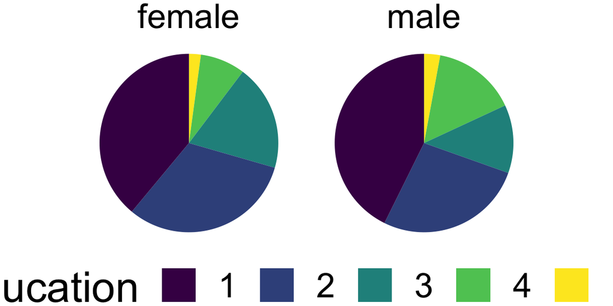

Why don't I like pie charts?

What we want from figures:

1. self-explanatory

2. important information should be easy to get

3. show trends (if available)

4. only as complicated as the data

5. free of unnecessary complexity
    - irrelavent decorations
    - 3D effects --(**BIG YIKES!!!!!**)

The pie chart violates 2, 4, and 5.

* 5: a bar chart is almost always more appropriate

* 2 and 4: pie charts compare angles. Humans are awful at comparing angles!

From [Wikimedia Commons](https://commons.wikimedia.org/wiki/File:Piecharts.svg)

For each of the following, rank the colors in terms of size:

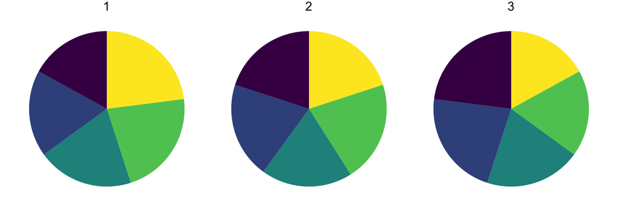

For each of the following, rank the colors in terms of size:

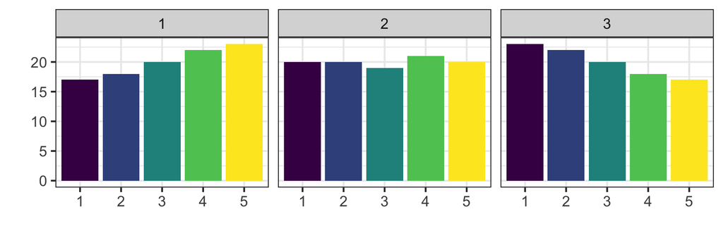

> "Only pie chart ever allowed:"
>

[figure not shown]

>
> <footer>--- Me (24/9/2019)</footer>

Before using a pie chart, read [this](https://www.richardhollins.com/blog/why-pie-charts-suck/), [this](https://policyviz.com/2018/01/11/fk-it-lets-use-pie-charts/), and [this](https://academy.datawrapper.de/article/127-what-to-consider-when-creating-a-pie-chart). [This](https://twitter.com/maxcroser/status/857389434756505600) Twitter thread is also great!